# Wine Class Classification

Daniel Lumban Gaol

24/04/2021

# 1. Librari and Setup

Pada metode klasifikasi menggunakan Regresi Logistik dan K-NN ini, sebelumnya Anda harus melakukan install.package() pada package readr, tidyverse, MASS, gtools, gmodels, class, caret, ggplot2 pada R Studio Anda. Apabila telah ter-install, maka lakukan pengaktifan package menggunakan library().

```r
library(gtools)
library(GGally)
library(gmodels)
library(class)
library(caret)
library(dplyr)
library(rsample)
```

# 2. Tujuan

Tujuan dari memprediksi data wine ini dari sifat fisiokimianya apakah yang membuat wine menjadi good atau not good berdasarkan qualitynya.

# 3. Logistic Regression

## 3.1 Import Data

```r
wine <- read.csv("winequality-red.csv")
head(wine)
```

```
#>   fixed.acidity volatile.acidity citric.acid residual.sugar chlorides
#> 1           7.4             0.70        0.00            1.9     0.076
#> 2           7.8             0.88        0.00            2.6     0.098
#> 3           7.8             0.76        0.04            2.3     0.092
#> 4          11.2             0.28        0.56            1.9     0.075
#> 5           7.4             0.70        0.00            1.9     0.076
#> 6           7.4             0.66        0.00            1.8     0.075
#>   free.sulfur.dioxide total.sulfur.dioxide density   pH sulphates alcohol
#> 1                  11                   34  0.9978 3.51      0.56     9.4
#> 2                  25                   67  0.9968 3.20      0.68     9.8
#> 3                  15                   54  0.9970 3.26      0.65     9.8
#> 4                  17                   60  0.9980 3.16      0.58     9.8
#> 5                  11                   34  0.9978 3.51      0.56     9.4
#> 6                  13                   40  0.9978 3.51      0.56     9.4
#>   quality
#> 1       5
#> 2       5
#> 3       5
#> 4       6
#> 5       5
#> 6       5
```

**Informasi Data :**

fixed.acidity : Sebagian besar asam yang terlibat dengan anggur

volatile.acidity : jumlah asam asetat dalam anggur

citric.acid : asam sitrat

residual.sugar : jumlah gula yang tersisa setelah fermentasi dihentikan

chlorides : jumlah garam dalam anggur

free.sulfur.dioxide : sebagai gas terlarut

total.sulfur.dioxide : jumlah formulir SO2 yang bebas dan terikat

density : kepadatan air mendekati air tergantung pada persen kandungan alkohol dan gula

pH : menjelaskan seberapa asam atau basa anggur dalam skala dari 0 (sangat asam) hingga 14 (sangat basa)

sulphates : aditif anggur yang dapat berkontribusi pada tingkat gas sulfur dioksida (S02)

alcohol : Kadar Alkohol

## 3.2 Data Manipulation

pada kolom quality terdapat tingkat quality wine yang dibuat oleh si pembuat data, bahwa dimana 6 > Good, 6 < Not Good, maka kita buat kolom baru

```r
wine$class <- ifelse(wine$quality <= 5 , "NotGood" , "Good")
```

Melakukan cek tipe data

```r
glimpse(wine)
```

```
#> Rows: 1,599
#> Columns: 13
#> $ fixed.acidity        <dbl> 7.4, 7.8, 7.8, 11.2, 7.4, 7.4, 7.9, 7.3, 7.8, 7.5~
#> $ volatile.acidity     <dbl> 0.700, 0.880, 0.760, 0.280, 0.700, 0.660, 0.600, ~
#> $ citric.acid          <dbl> 0.00, 0.00, 0.04, 0.56, 0.00, 0.00, 0.06, 0.00, 0~
#> $ residual.sugar       <dbl> 1.9, 2.6, 2.3, 1.9, 1.9, 1.8, 1.6, 1.2, 2.0, 6.1,~
#> $ chlorides            <dbl> 0.076, 0.098, 0.092, 0.075, 0.076, 0.075, 0.069, ~
#> $ free.sulfur.dioxide  <dbl> 11, 25, 15, 17, 11, 13, 15, 15, 9, 17, 15, 17, 16~
#> $ total.sulfur.dioxide <dbl> 34, 67, 54, 60, 34, 40, 59, 21, 18, 102, 65, 102,~
#> $ density              <dbl> 0.9978, 0.9968, 0.9970, 0.9980, 0.9978, 0.9978, 0~
#> $ pH                   <dbl> 3.51, 3.20, 3.26, 3.16, 3.51, 3.51, 3.30, 3.39, 3~
#> $ sulphates            <dbl> 0.56, 0.68, 0.65, 0.58, 0.56, 0.56, 0.46, 0.47, 0~
#> $ alcohol              <dbl> 9.4, 9.8, 9.8, 9.8, 9.4, 9.4, 9.4, 10.0, 9.5, 10.~
#> $ quality              <int> 5, 5, 5, 6, 5, 5, 5, 7, 7, 5, 5, 5, 5, 5, 5, 5, 7~
#> $ class                <chr> "NotGood", "NotGood", "NotGood", "Good", "NotGood~
```

Menghapus kolom dan merubah tipe data

```r
wine_clean <- wine %>%
            mutate(class = as.factor(class)) %>%
            select(-quality)
glimpse(wine_clean)
```

```
#> Rows: 1,599
#> Columns: 12
#> $ fixed.acidity        <dbl> 7.4, 7.8, 7.8, 11.2, 7.4, 7.4, 7.9, 7.3, 7.8, 7.5~
#> $ volatile.acidity     <dbl> 0.700, 0.880, 0.760, 0.280, 0.700, 0.660, 0.600, ~
#> $ citric.acid          <dbl> 0.00, 0.00, 0.04, 0.56, 0.00, 0.00, 0.06, 0.00, 0~
#> $ residual.sugar       <dbl> 1.9, 2.6, 2.3, 1.9, 1.9, 1.8, 1.6, 1.2, 2.0, 6.1,~
#> $ chlorides            <dbl> 0.076, 0.098, 0.092, 0.075, 0.076, 0.075, 0.069, ~
#> $ free.sulfur.dioxide  <dbl> 11, 25, 15, 17, 11, 13, 15, 15, 9, 17, 15, 17, 16~
#> $ total.sulfur.dioxide <dbl> 34, 67, 54, 60, 34, 40, 59, 21, 18, 102, 65, 102,~
#> $ density              <dbl> 0.9978, 0.9968, 0.9970, 0.9980, 0.9978, 0.9978, 0~
#> $ pH                   <dbl> 3.51, 3.20, 3.26, 3.16, 3.51, 3.51, 3.30, 3.39, 3~
#> $ sulphates            <dbl> 0.56, 0.68, 0.65, 0.58, 0.56, 0.56, 0.46, 0.47, 0~
#> $ alcohol              <dbl> 9.4, 9.8, 9.8, 9.8, 9.4, 9.4, 9.4, 10.0, 9.5, 10.~
#> $ class                <fct> NotGood, NotGood, NotGood, Good, NotGood, NotGood~
```

Melakukan Pengecekan terhadap missing value

```r
colSums(is.na(wine_clean))
```

```
#>        fixed.acidity     volatile.acidity          citric.acid
#>                    0                    0                    0
#>       residual.sugar            chlorides  free.sulfur.dioxide
#>                    0                    0                    0
#> total.sulfur.dioxide              density                   pH
#>                    0                    0                    0
#>            sulphates              alcohol                class
#>                    0                    0                    0
```

## 3.3 Exploratory Data Analysis

Membuat data training dan data testing dengan cara split Asumsi : 80% Data akan dibuat menjadi data train dan 20% menjadi data test

```r
RNGkind(sample.kind = "Rounding")
set.seed(105)


intrain <- initial_split(data = wine_clean, prop = 0.8, strata = class)
wine.train <- training(intrain)
wine.test <- training(intrain)
```

```r
prop.table(table(wine.train$class))
```

```
#>
#>      Good   NotGood
#> 0.5347385 0.4652615
```

```r
prop.table(table(wine.test$class))
```

```
#>
#>      Good   NotGood
#> 0.5347385 0.4652615
```

Membuat data menjadi balance dengan teknik upSample :

```r
wine.up <- upSample(x = wine.train %>% select(-class),
                    y = wine.test$class,
                    yname = "class")

prop.table(table(wine.up$class))
```

```
#>
#>    Good NotGood
#>     0.5     0.5
```

Melakukan pemodelan menggunakan regresi logistik. Pemodelan menggunakan fungsi glm dalam memodelkan menggunakan regresi logistik. Variabel yang digunakan adalah semua variabel, dimana variabel target menjadi variabel responnya.

```r
model.wine <- glm(class ~ ., wine.up,family = "binomial")
summary(model.wine)
```

```
#>
#> Call:
#> glm(formula = class ~ ., family = "binomial", data = wine.up)
#>
#> Deviance Residuals:
#>     Min       1Q   Median       3Q      Max
#> -2.2972  -0.8362  -0.0158   0.8475   3.3631
#>
#> Coefficients:
#>                        Estimate Std. Error z value          Pr(>|z|)
#> (Intercept)          -71.043676  85.234651  -0.834          0.404559
#> fixed.acidity         -0.162360   0.104959  -1.547          0.121892
#> volatile.acidity       2.919646   0.519284   5.622 0.000000018827142 ***
#> citric.acid            1.409508   0.598782   2.354          0.018575 *
#> residual.sugar        -0.083355   0.056037  -1.488          0.136879
#> chlorides              4.000311   1.763209   2.269          0.023283 *
#> free.sulfur.dioxide   -0.029415   0.008720  -3.373          0.000743 ***
#> total.sulfur.dioxide   0.018372   0.003169   5.798 0.000000006724568 ***
#> density               78.326857  87.018368   0.900          0.368057
#> pH                     0.633340   0.753392   0.841          0.400543
#> sulphates             -2.631372   0.444718  -5.917 0.000000003279847 ***
#> alcohol               -0.820524   0.108046  -7.594 0.000000000000031 ***
#> ---
#> Signif. codes:  0 '***' 0.001 '**' 0.01 '*' 0.05 '.' 0.1 ' ' 1
#>
#> (Dispersion parameter for binomial family taken to be 1)
#>
#>     Null deviance: 1899.2  on 1369  degrees of freedom
#> Residual deviance: 1435.9  on 1358  degrees of freedom
#> AIC: 1459.9
#>
#> Number of Fisher Scoring iterations: 4
```

Dari hasil diatas, prediktor yang memiliki korelasi kuat dengan target variabel (class) adalah volatile.acidity, citric.acid, chlorides, free.sulfur.dioxide, total.sulfur.dioxide, sulphates dan alcohol. Tetapi kita akan mencoba model fitting dengan menggunakan metode stepwise

```r
model.wine2 <- step(model.wine, direction = "both")
```

```
#> Start:  AIC=1459.89
#> class ~ fixed.acidity + volatile.acidity + citric.acid + residual.sugar +
#>     chlorides + free.sulfur.dioxide + total.sulfur.dioxide +
#>     density + pH + sulphates + alcohol
#>
#>                        Df Deviance    AIC
#> - pH                    1   1436.6 1458.6
#> - density               1   1436.7 1458.7
#> <none>                      1435.9 1459.9
#> - residual.sugar        1   1438.1 1460.1
#> - fixed.acidity         1   1438.3 1460.3
#> - chlorides             1   1441.3 1463.3
#> - citric.acid           1   1441.5 1463.5
#> - free.sulfur.dioxide   1   1447.4 1469.4
#> - volatile.acidity      1   1470.5 1492.5
#> - total.sulfur.dioxide  1   1472.6 1494.6
#> - sulphates             1   1475.7 1497.7
#> - alcohol               1   1497.6 1519.6
#>
#> Step:  AIC=1458.59
#> class ~ fixed.acidity + volatile.acidity + citric.acid + residual.sugar +
#>     chlorides + free.sulfur.dioxide + total.sulfur.dioxide +
#>     density + sulphates + alcohol
#>
#>                        Df Deviance    AIC
#> <none>                      1436.6 1458.6
#> - density               1   1439.5 1459.5
#> + pH                    1   1435.9 1459.9
#> - residual.sugar        1   1440.2 1460.2
#> - chlorides             1   1441.3 1461.3
#> - citric.acid           1   1442.4 1462.4
#> - fixed.acidity         1   1446.9 1466.9
#> - free.sulfur.dioxide   1   1447.5 1467.5
#> - volatile.acidity      1   1471.7 1491.7
#> - total.sulfur.dioxide  1   1472.8 1492.8
#> - sulphates             1   1479.4 1499.4
#> - alcohol               1   1512.0 1532.0
```

```r
summary(model.wine2)
```

```
#>
#> Call:
#> glm(formula = class ~ fixed.acidity + volatile.acidity + citric.acid +
#>     residual.sugar + chlorides + free.sulfur.dioxide + total.sulfur.dioxide +
#>     density + sulphates + alcohol, family = "binomial", data = wine.up)
#>
#> Deviance Residuals:
#>     Min       1Q   Median       3Q      Max
#> -2.2809  -0.8338  -0.0128   0.8384   3.4043
#>
#> Coefficients:
#>                         Estimate  Std. Error z value             Pr(>|z|)
#> (Intercept)          -110.783469   70.935246  -1.562              0.11835
#> fixed.acidity          -0.227354    0.071291  -3.189              0.00143 **
#> volatile.acidity        2.935458    0.518192   5.665       0.000000014719 ***
#> citric.acid             1.427596    0.597256   2.390              0.01684 *
#> residual.sugar         -0.099524    0.052596  -1.892              0.05846 .
#> chlorides               3.642576    1.707723   2.133              0.03292 *
#> free.sulfur.dioxide    -0.028284    0.008632  -3.277              0.00105 **
#> total.sulfur.dioxide    0.017819    0.003094   5.759       0.000000008479 ***
#> density               120.472457   71.142533   1.693              0.09038 .
#> sulphates              -2.681732    0.437651  -6.128       0.000000000892 ***
#> alcohol                -0.775480    0.093565  -8.288 < 0.0000000000000002 ***
#> ---
#> Signif. codes:  0 '***' 0.001 '**' 0.01 '*' 0.05 '.' 0.1 ' ' 1
#>
#> (Dispersion parameter for binomial family taken to be 1)
#>
#>     Null deviance: 1899.2  on 1369  degrees of freedom
#> Residual deviance: 1436.6  on 1359  degrees of freedom
#> AIC: 1458.6
#>
#> Number of Fisher Scoring iterations: 4
```

Mencoba untuk menginterpretasikan salah satu prediktor numerik yaitu alcohol :

```r
#alcohol
inv.logit(-0.775480)
```

```
#> [1] 0.3152949
```

Klasifikasikan data wine.test berdasarkan `prediksi` dan simpan pada kolom baru bernama `prediksi`.

Prediksi:

```r
wine.test$prediksi <- predict(object = model.wine2,
                              newdata = wine.test,
                              type = "response")
```

Cek persebaran data

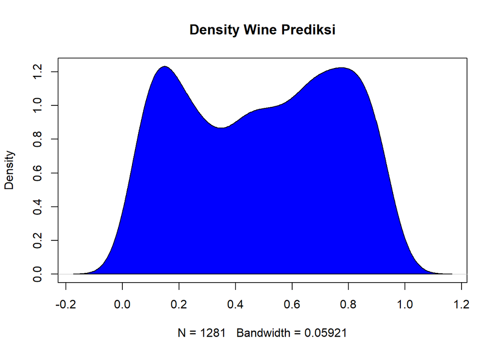

```r
plot.wine <- density(wine.test$prediksi)
plot(plot.wine, main = "Density Wine Prediksi")
polygon(plot.wine, col="blue", border="black")
```

Hasil Prediksi

```r
wine.test$pred.label <- ifelse(wine.test$prediksi < 0.5, "NotGood" , "Good" )

wine.test$pred.label <- as.factor(wine.test$pred.label)
str(wine.test)
```

```
#> 'data.frame':    1281 obs. of  14 variables:
#>  $ fixed.acidity       : num  7.4 7.8 7.8 11.2 7.4 7.4 7.3 7.8 6.7 7.5 ...
#>  $ volatile.acidity    : num  0.7 0.88 0.76 0.28 0.7 0.66 0.65 0.58 0.58 0.5 ...
#>  $ citric.acid         : num  0 0 0.04 0.56 0 0 0 0.02 0.08 0.36 ...
#>  $ residual.sugar      : num  1.9 2.6 2.3 1.9 1.9 1.8 1.2 2 1.8 6.1 ...
#>  $ chlorides           : num  0.076 0.098 0.092 0.075 0.076 0.075 0.065 0.073 0.097 0.071 ...
#>  $ free.sulfur.dioxide : num  11 25 15 17 11 13 15 9 15 17 ...
#>  $ total.sulfur.dioxide: num  34 67 54 60 34 40 21 18 65 102 ...
#>  $ density             : num  0.998 0.997 0.997 0.998 0.998 ...
#>  $ pH                  : num  3.51 3.2 3.26 3.16 3.51 3.51 3.39 3.36 3.28 3.35 ...
#>  $ sulphates           : num  0.56 0.68 0.65 0.58 0.56 0.56 0.47 0.57 0.54 0.8 ...
#>  $ alcohol             : num  9.4 9.8 9.8 9.8 9.4 9.4 10 9.5 9.2 10.5 ...
#>  $ class               : Factor w/ 2 levels "Good","NotGood": 2 2 2 1 2 2 1 1 2 2 ...
#>  $ prediksi            : num  0.8 0.782 0.758 0.51 0.8 ...
#>  $ pred.label          : Factor w/ 2 levels "Good","NotGood": 1 1 1 1 1 1 1 1 1 1 ...
```

Melihat hasil prediksi

```r
wine.test %>%
  select(class,prediksi,pred.label) %>%
  head()
```

```
#>     class  prediksi pred.label
#> 1 NotGood 0.8001999       Good
#> 2 NotGood 0.7816065       Good
#> 3 NotGood 0.7583462       Good
#> 4    Good 0.5100959       Good
#> 5 NotGood 0.8001999       Good
#> 6 NotGood 0.7903084       Good
```

```r
wine.conf <- confusionMatrix(wine.test$pred.label, wine.test$class, positive = "NotGood")
wine.conf
```

```
#> Confusion Matrix and Statistics
#>
#>           Reference
#> Prediction Good NotGood
#>    Good     189     462
#>    NotGood  496     134
#>
#>                Accuracy : 0.2521
#>                  95% CI : (0.2286, 0.2769)
#>     No Information Rate : 0.5347
#>     P-Value [Acc > NIR] : 1.0000
#>
#>                   Kappa : -0.4974
#>
#>  Mcnemar's Test P-Value : 0.2863
#>
#>             Sensitivity : 0.2248
#>             Specificity : 0.2759
#>          Pos Pred Value : 0.2127
#>          Neg Pred Value : 0.2903
#>              Prevalence : 0.4653
#>          Detection Rate : 0.1046
#>    Detection Prevalence : 0.4918
#>       Balanced Accuracy : 0.2504
#>
#>        'Positive' Class : NotGood
#>
```

4 metrics performa model: Accuracy, Sensitivity/Recall, Precision/Pos pred Value, Specificity

Dari hasil prediksi diatas model yang dihasilkan hanya mendapatkan accuracy 25%, dibalik tingkat akurasi tersebut jika menjawab dari business question dimana memfokuskan terhadap quality dari wine tersebut. Maka bisa memainkan tingkat dari threshold/ambang batasnya, dimana kita bisa menaikan threshold dari 0.5 menjadi 0.8, untuk mendapatkan Sensitivity atau recall yang tinggi untuk mendapatkan quality yang baik dan memperkecil NotGood.

# 4. K-Nearest Neighbour

Untuk menjawab kelanjutan dari model sebelumnya, dimana tingkat accuracy masih rendah, pada tahap ini akan digunakan model K-NN untuk mengetahui apakah dengan model ini tingkat accuracy akan menjadi lebih baik terhadap quality wine tersebut

## 4.1 Cross Validation

```r
wine.scale <- wine.up %>%
  mutate(class = as.factor(class))
```

Membuat data training dan data testing dari data wine.scale

```r
RNGkind(sample.kind = "Rounding")
set.seed(105)

init <- initial_split(wine.up, prop = 0.8, strara = "class")
ws.train <- training(init)
ws.test <- testing(init)
```

check class balance

```r
prop.table(table(ws.train$class))
```

```
#>
#>      Good   NotGood
#> 0.4977211 0.5022789
```

```r
prop.table(table(ws.test$class))
```

```
#>
#>      Good   NotGood
#> 0.5091575 0.4908425
```

## 4.2 Data Training

Pada model k-NN, dipisahkan antara prediktor dan label (target variabelnya).

```r
#Prediktor
ws.train.x <- ws.train %>%
  select(-class)

ws.test.x <- ws.test %>%
  select(-class)

#Target
ws.train.y <- ws.train %>%
  select(class)

ws.test.y <- ws.test %>%
  select(class)
```

Scaling data

```r
ws.train.xs <- ws.train.x %>%
              select_if(is.numeric) %>%
              scale()

ws.test.xs <- ws.test.x %>%
              select_if(is.numeric) %>%
              scale()
```

## 4.3

mencari K yang optimum

```r
sqrt(nrow(ws.train.x))
```

```
#> [1] 33.12099
```

```r
wine.prediksi <- knn(train = ws.train.xs,
                     test = ws.test.xs,
                     cl = ws.train.y$class,
                     k = 33)
head(wine.prediksi)
```

```
#> [1] NotGood NotGood NotGood Good    Good    Good
#> Levels: Good NotGood
```

```r
confusionMatrix(data = wine.prediksi,
                reference = as.factor(ws.test.y$class),
                positive = "NotGood")
```

```
#> Confusion Matrix and Statistics
#>
#>           Reference
#> Prediction Good NotGood
#>    Good     107      30
#>    NotGood   32     104
#>
#>                Accuracy : 0.7729
#>                  95% CI : (0.7185, 0.8212)
#>     No Information Rate : 0.5092
#>     P-Value [Acc > NIR] : <0.0000000000000002
#>
#>                   Kappa : 0.5458
#>
#>  Mcnemar's Test P-Value : 0.8989
#>
#>             Sensitivity : 0.7761
#>             Specificity : 0.7698
#>          Pos Pred Value : 0.7647
#>          Neg Pred Value : 0.7810
#>              Prevalence : 0.4908
#>          Detection Rate : 0.3810
#>    Detection Prevalence : 0.4982
#>       Balanced Accuracy : 0.7730
#>
#>        'Positive' Class : NotGood
#>
```

# 5. Kesimpulan

Berdasarkan hasil prediksi yang diperoleh dari logistic regression dan K-NN, dapat disimpulkan bahwa dalam case ini kedua model tidak memiliki kemampuan yang sama dalam melakukan prediksi. Hal ini dikarenakan kedua model memiliki accuracy, sensitivity, specifivity dan pos pred value yang berbeda jauh, sehingga pada case ini model dengan K-NN adalah model yang lebih tepat dalam melakukan prediksi dengan accuracy 77%